# je moeder

## Hier is nog een plot

```r
library(novalinq.brush)
range_pal <- hsv_range(input = c("#E2E2F7", "#161825"), s = c(.59, .94, .75, 1), n = 13)

range_pal
```

```
##  [1] "#E2E2F7" "#C2C2E6" "#A7A8D4" "#9091C3" "#7C7EB1" "#6A6DA0" "#5B5F8E"
##  [8] "#4E517D" "#41456B" "#36395A" "#2B2E48" "#202337" "#161825"
```

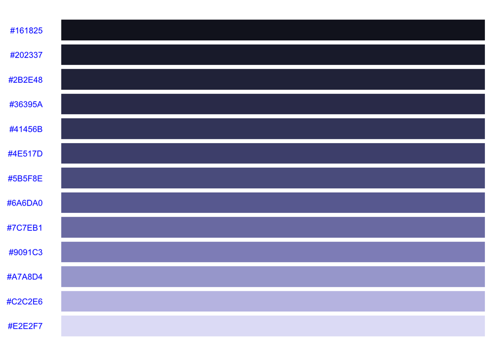

```r
show_palette(range_pal)
```

```r
your_mother <- function(x, a = 1, b = 1, c = 1) {

  require(ggplot2)

  d = data.frame(x = x, y = a*x^2 + b*x + c)

  ggplot(d, aes(x = d$x, y = d$y)) +
    geom_line() +
    coord_fixed(ratio = .02)


}

sqrt(20/6)
```

```
## [1] 1.825742
```

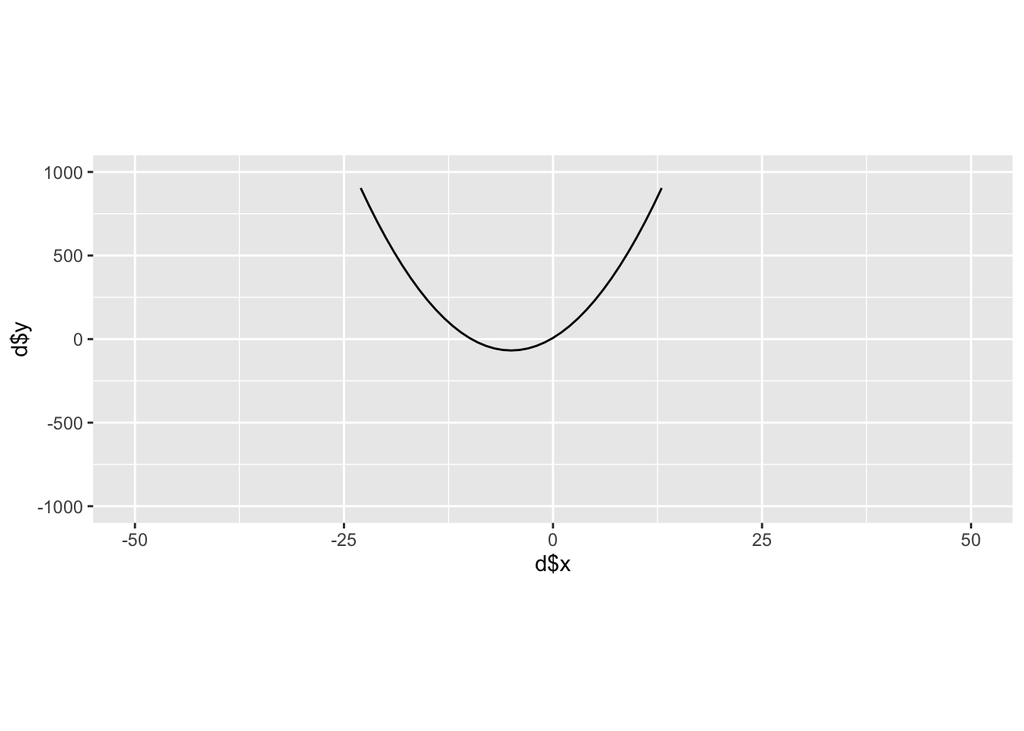

```r
your_mother(-100:100, a = 3, b = 30, c = 7) +
  xlim(c(-50, 50)) +
  ylim(c(-1000, 1000))
```

```r
ym2 <- function(x = -100:100, a = 0, b = 0, c = 0, d = 0) {

  d <- data.frame(x = x, y = a*(x^3) + b*(x^2) + c*x + d)

  ggplot(d, aes(x = d$x, y = d$y)) +
    geom_line() +
    coord_fixed(ratio = .02)

}

quad <- function(a,b,c){
  c(
    (-b + sqrt(b^2 - 4*a*c))/(2*a),
    (-b - sqrt(b^2 - 4*a*c))/(2*a)
    )
}

quad(a = 3, b = 30, c = 7)
```

```
## [1] -0.2390477 -9.7609523
```

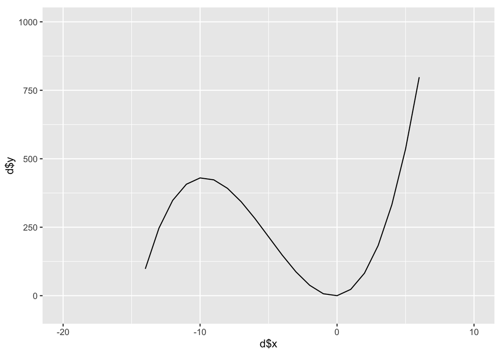

```r
ym2(a = 1, b = 15, c = 7) +
  xlim(c(-20, 10)) +
  ylim(c(-50, 1000))
```